# Data Analysis 1

2023-12-06

### Loading in Necessary Packages and Functions

```r
library(tidyverse)
library(psych)
library(car)
library(effectsize)
library(gridExtra)
library(dplyr)
library(tinytex)
library(ggplot2)
library(janitor)
library(data.table)
library(rockchalk)
library(dplyr)
library(sjmisc)
source("C:/Users/16089/OneDrive/Desktop/750 submit/Functions.R")
```

### load in data and convert variables to snake case

```r
d <- read.csv("C:/Users/16089/OneDrive/Desktop/merged_2.csv")
d_f <- clean_names(d, case = "snake")
```

# Model Analysis 1

## Analysing Hypothesized Model

Research Question 1: Is the effect of infectious rate on closure moderated by the the industrial sector’s share of GDP?

```r
d_f$infectious_rate <- as.numeric(d_f$cumulative_cases) / as.numeric(d_f$population)
mod_1 <- lm(closure ~ infectious_rate*industry, data = d_f)
summary(mod_1)
```

```
##
## Call:
## lm(formula = closure ~ infectious_rate * industry, data = d_f)
##
## Residuals:
##      Min       1Q   Median       3Q      Max
## -1155.79  -207.54    14.96   221.50   557.36
##
## Coefficients:
##                          Estimate Std. Error t value Pr(>|t|)
## (Intercept)                654.51     105.54   6.201 5.84e-09 ***
## infectious_rate          12749.02    4183.98   3.047  0.00276 **
## industry                    16.07       3.90   4.120 6.44e-05 ***
## infectious_rate:industry  -360.69     152.20  -2.370  0.01915 *
## ---
## Signif. codes:  0 '***' 0.001 '**' 0.01 '*' 0.05 '.' 0.1 ' ' 1
##
## Residual standard error: 316.3 on 141 degrees of freedom
##   (1 observation deleted due to missingness)
## Multiple R-squared:  0.1392, Adjusted R-squared:  0.1209
## F-statistic:   7.6 on 3 and 141 DF,  p-value: 9.527e-05
```

The interaction seems to be significant according to the model summary, let’s test the data against General Linear Model’s assumptions:

## Categorizing Quantitative Variable And Testing Model Assumptions

Before testing model assumptions, since both variables under interaction term are quantitative, for convenience of analysis and visualization, we we group the continuous values of proportion of industrial sectors’ contribution to GDP into categories of “High”, “Low” and “Medium”, and put them back into the model:

```r
d_f$infectious_rate <- as.numeric(d_f$cumulative_cases) / as.numeric(d_f$population)
d_f$infectious_rate_t <- d_f$infectious_rate^.5
mean_industry <- mean(d_f$industry)
# Calculate standard deviations for 'industry'
std_dev = sd(d$industry)
d$industry_plus = d$industry + std_dev
d$industry_minus = d$industry - std_dev

d_f <- d_f %>%
  mutate(industry_group = case_when(
    industry < mean_industry - std_dev ~ "Low(> 1 sd above the mean)",
    industry > mean_industry + std_dev ~ "High(< 1 sd below the mean)",
    TRUE ~ "Medium"
  ))

d_f$industry_group <- as.factor(d_f$industry_group)

# Relevel to make 'Low' the reference group
d_f$industry_group <- relevel(d_f$industry_group, ref = "Low(> 1 sd above the mean)")
mod1_low <- lm(closure ~ infectious_rate, data = d_f[d_f$industry_group == "Low(> 1 sd above the mean)", ])

# Relevel to make 'Medium' the reference group
d_f$industry_group <- relevel(d_f$industry_group, ref = "Medium")
mod1_medium <- lm(closure ~ infectious_rate, data = d_f[d_f$industry_group == "Medium",])

d_f$industry_group <- relevel(d_f$industry_group, ref = "High(< 1 sd below the mean)")
mod1_high <- lm(closure ~ infectious_rate, data = d_f[d_f$industry_group == "High(< 1 sd below the mean)",])
```

### Testing Against Normality Distribution of Error

test the model for data that are in “Low” industry group

```r
x_norms1 <- modelAssumptions(mod1_low, "NORMAL")
```

```
## Descriptive Statistics for Studentized Residuals
```

test the model for data that are in “Medium” industry group

```r
x_norms2 <- modelAssumptions(mod1_medium, "NORMAL")
```

```
## Descriptive Statistics for Studentized Residuals
```

test the model for data that are in “High” industry group

```r
x_norms3 <- modelAssumptions(mod1_high, "NORMAL")
```

```
## Descriptive Statistics for Studentized Residuals
```

### Testing Against Constant Variance of Error

test the model for data that are in “Low” industry group

```r
x_constant1 <-  modelAssumptions(mod1_low, "CONSTANT")
```

```
##
## Suggested power transformation:  0.115585
##
##
## Non-constant Variance Score Test
## Variance formula: ~ fitted.values
## Chisquare = 0.1432815, Df = 1, p = 0.70504
```

test the model for data that are in “Medium” industry group

```r
x_constant2 <- modelAssumptions(mod1_medium, "CONSTANT")
```

```
##
## Suggested power transformation:  1.609729
##
##
## Non-constant Variance Score Test
## Variance formula: ~ fitted.values
## Chisquare = 1.434343, Df = 1, p = 0.23106
```

test the model for data that are in “High” industry group

```r
x_constant3 <- modelAssumptions(mod1_high, "CONSTANT")
```

```
##
## Suggested power transformation:  -0.2373727
##
##
## Non-constant Variance Score Test
## Variance formula: ~ fitted.values
## Chisquare = 1.109303, Df = 1, p = 0.29223
```

### Testing Against Linearity

test the model for data that are in “Low” industry group

```r
x_linear1 <- modelAssumptions(mod1_low, "LINEAR")
```

[output not shown]

test the model for data that are in “Medium” industry group

```r
x_linear2 <- modelAssumptions(mod1_medium, "LINEAR")
```

[output not shown]

test the model for data that are in “High” industry group

```r
x_linear3 <- modelAssumptions(mod1_high, "LINEAR")
```

[output not shown]

## Apply Transformation to a predictor and Test the Model Assumptions

We transformed the predictor and fit it into the model

```r
d_f$infectious_rate <- as.numeric(d_f$cumulative_cases) / as.numeric(d_f$population)
d_f$infectious_rate_t <- d_f$infectious_rate^.5
mod_1p <- lm(closure ~ infectious_rate_t*industry, data = d_f)

d_f$industry_group <- relevel(d_f$industry_group, ref = "Low(> 1 sd above the mean)")
mod1_tlow <- lm(closure ~ infectious_rate_t, data = d_f[d_f$industry_group == "Low(> 1 sd above the mean)", ])

# Relevel to make 'Medium' the reference group
d_f$industry_group <- relevel(d_f$industry_group, ref = "Medium")
mod1_tmedium <- lm(closure ~ infectious_rate_t, data = d_f[d_f$industry_group == "Medium",])

d_f$industry_group <- relevel(d_f$industry_group, ref = "High(< 1 sd below the mean)")
mod1_thigh <- lm(closure ~ infectious_rate_t, data = d_f[d_f$industry_group == "High(< 1 sd below the mean)",])
```

### Testing Transformed Model Against Normality Distribution of Error

test the model for data that are in “Low” industry group

```r
x_norm1t <- modelAssumptions(mod1_tlow, "NORMAL")
```

```
## Descriptive Statistics for Studentized Residuals
```

test the model for data that are in “Medium” industry group

```r
x_norm2t <- modelAssumptions(mod1_tmedium, "NORMAL")
```

```
## Descriptive Statistics for Studentized Residuals
```

test the model for data that are in “High” industry group

```r
x_norm3t <- modelAssumptions(mod1_thigh, "NORMAL")
```

```
## Descriptive Statistics for Studentized Residuals
```

### Testing Against Constant Variance of Error

test the model for data that are in “Low” industry group

```r
x_const1t <- modelAssumptions(mod1_tlow, "CONSTANT")
```

```
##
## Suggested power transformation:  0.4283853
##
##
## Non-constant Variance Score Test
## Variance formula: ~ fitted.values
## Chisquare = 0.03584375, Df = 1, p = 0.84984
```

test the model for data that are in “Medium” industry group

```r
x_const2t <- modelAssumptions(mod1_tmedium, "CONSTANT")
```

```
##
## Suggested power transformation:  1.481319
##
##
## Non-constant Variance Score Test
## Variance formula: ~ fitted.values
## Chisquare = 0.8103501, Df = 1, p = 0.36802
```

test the model for data that are in “High” industry group

```r
x_const3t <- modelAssumptions(mod1_thigh, "CONSTANT")
```

```
##
## Suggested power transformation:  -1.595035
##
##
## Non-constant Variance Score Test
## Variance formula: ~ fitted.values
## Chisquare = 1.615103, Df = 1, p = 0.20378
```

### Testing Against Linearity

test the model for data that are in “Low” industry group

```r
x_lin1 <- modelAssumptions(mod1_tlow, "LINEAR")
```

[output not shown]

test the model for data that are in “Medium” industry group

```r
x_lin2 <- modelAssumptions(mod1_tmedium, "LINEAR")
```

[output not shown]

test the model for data that are in “High” industry group

```r
x_lin3 <- modelAssumptions(mod1_thigh,"LINEAR")
```

[output not shown]

## Analysing Model After Application of Transformation

```r
mod_1t <- lm(closure ~ infectious_rate_t*industry, data = d_f)
summary(mod_1t)
```

```
##
## Call:
## lm(formula = closure ~ infectious_rate_t * industry, data = d_f)
##
## Residuals:
##     Min      1Q  Median      3Q     Max
## -1171.3  -190.3    17.1   227.9   487.8
##
## Coefficients:
##                            Estimate Std. Error t value Pr(>|t|)
## (Intercept)                 478.694    126.236   3.792 0.000221 ***
## infectious_rate_t          3782.265    970.915   3.896 0.000151 ***
## industry                     20.691      4.721   4.382 2.28e-05 ***
## infectious_rate_t:industry -103.701     36.246  -2.861 0.004866 **
## ---
## Signif. codes:  0 '***' 0.001 '**' 0.01 '*' 0.05 '.' 0.1 ' ' 1
##
## Residual standard error: 307.4 on 141 degrees of freedom
##   (1 observation deleted due to missingness)
## Multiple R-squared:  0.187,  Adjusted R-squared:  0.1697
## F-statistic: 10.81 on 3 and 141 DF,  p-value: 1.943e-06
```

```r
car::Anova(mod_1t, type = 3) %>% eta_squared()
```

```
## Type 3 ANOVAs only give sensible and informative results when covariates
##   are mean-centered and factors are coded with orthogonal contrasts (such
##   as those produced by `contr.sum`, `contr.poly`, or `contr.helmert`, but
##   *not* by the default `contr.treatment`).
```

```
## # Effect Size for ANOVA (Type III)
##
## Parameter                  | Eta2 (partial) |       95% CI
## ----------------------------------------------------------
## infectious_rate_t          |           0.10 | [0.03, 1.00]
## industry                   |           0.12 | [0.05, 1.00]
## infectious_rate_t:industry |           0.05 | [0.01, 1.00]
##
## - One-sided CIs: upper bound fixed at [1.00].
```

The standard error for interaction term has decreased after applying transformation

### Plotting the graph

[figure not shown]

```r
# Plot
ggplot(d_f, aes(x = infectious_rate_t, y = closure, color = industry_group)) +
  geom_point() +
  geom_smooth(method = "lm", se = FALSE) +
  theme_minimal() +
  labs(title = "Relationship between Closure Level and Infectious Rate",
       x = "Infectious Rate (cumulative cases/population)",
       y = "Closure Level(higher index higher strictness)",
       color = "the level of\nIndustrial sectors\ncontribution to GDP in %",
       caption = str_wrap("Closure Level:The data is from Our World in Data website. It includes workplace closure level during the pandemic by country. The higher index represents higher strictness of countries closure policy. https://ourworldindata.org/covid-school-workplace-closures; GDP composition: The data comes from The World Bank. It includes GDP composition by agriculture, industry and service by country, https://wdi.worldbank.org/table/4.2#; Population: The data comes from Worldometer website, https://www.worldometers.info/world-population/population-by-country/#google_vignette", 120)) + theme(plot.title = element_text(size = 13, hjust = 0), legend.title = element_text(size = 10, margin = margin(t = -2, b = -2)),
    legend.box = "none", plot.caption = element_text(hjust = 0))
```

Our hypothesis is confirmed. Countries that rely heavily on industrial output for a large part of their economic activity might face greater economic challenges due to the closure of workplaces. To preserve their economic stability, these countries might be more hesitant to shut down workplaces.

## Analysing the Outlier

```r
x_cooks <- modelCaseAnalysis(mod_1t, Type = "COOKSD")
```

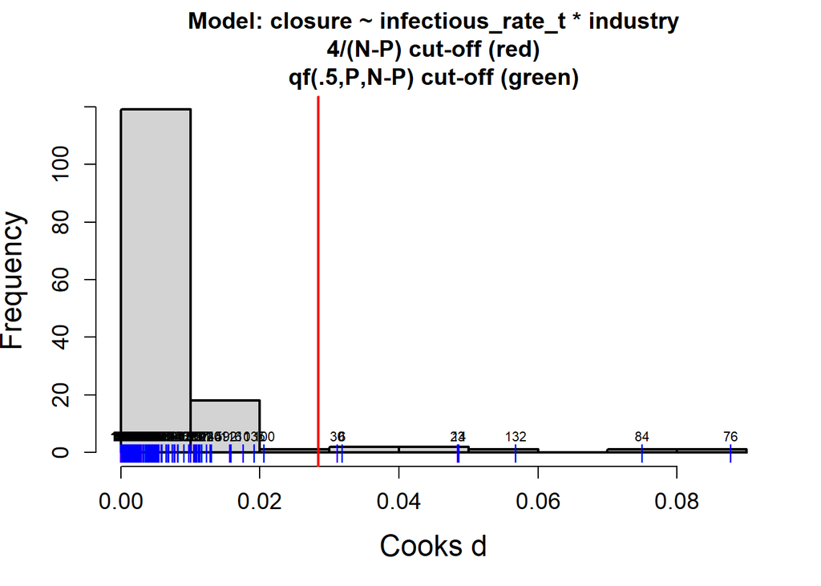

Look up the outliers

```r
d_f[c(76, 84), ]
```

```
##    unnamed_0    country closure  gdp agriculture industry manufacturing
## 76        81   Kiribati      63  0.2        26.7     10.0           4.4
## 84        90 Luxembourg     861 74.0         0.2     11.3           5.0
##    services population yearly_change net_change density_p_km land_area_km
## 76     69.2     133515         1.74%      2,283          165          810
## 84     79.8     654768         1.11%      7,169          253         2590
##    migrants_net fert_rate med_age urban_pop world_share    sum_im     sum_ex
## 76         -400       3.2      22       56%       0.00%   181.204   120.5573
## 84         4883       1.4      39       88%       0.01% 14512.064 21887.2912
##    cumulative_cases cumulative_deaths infectious_rate infectious_rate_t
## 76                0                 0      0.00000000         0.0000000
## 84            38383               285      0.05862076         0.2421173
##                industry_group
## 76 Low(> 1 sd above the mean)
## 84 Low(> 1 sd above the mean)
```

Look at the influence plot

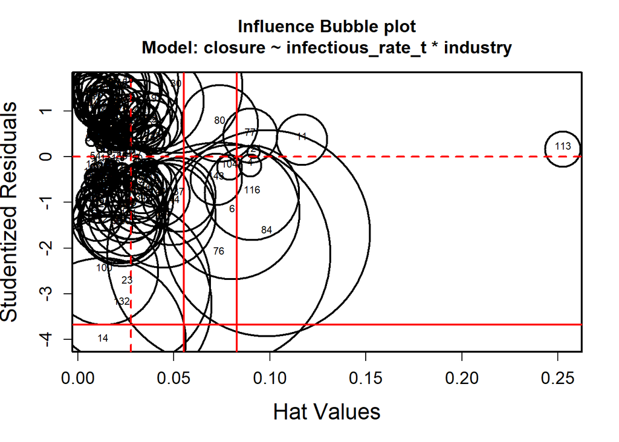

```r
x_infs <- modelCaseAnalysis(mod_1p, Type = "INFLUENCEPLOT")
```